# Exploratory Data Analysis

Author

Theresa Binnings (and Judith Canner)

# dplyr - `summarize()`

## Compute a table of summaries

```r
babynames |>
  summarize(total = sum(n),
            max = max(n))
```

```
# A tibble: 1 × 2
      total   max
      <dbl> <dbl>
1 310909342 99693
```

## Your Turn 1

Complete the code below to extract the rows where `name == "Lincoln"`. Then use `summarise()` and `sum()` and `min()` to find:

1. The total number of children named Lincoln
2. The first year Lincoln appeared in the data

*(Hint: Be sure to remove each `_` before running the code)*

```r
babynames |>
  filter(name == "Lincoln") |>
  summarise(total = sum(n),
              first = min(year))
```

```
# A tibble: 1 × 2
  total first
  <dbl> <dbl>
1 83814  1891
```

## The `n()` Function

The `n()` function does not need any input. It simply counts the number of rows in the data frame or tibble.

```r
babynames |>
  summarize(row_n = n())
```

```
# A tibble: 1 × 1
   row_n
   <int>
1 144000
```

## The `n_distinct()` Function

```r
babynames |>
  summarize(row_n = n(),
            name_n = n_distinct(name))
```

```
# A tibble: 1 × 2
   row_n name_n
   <int>  <int>
1 144000   3373
```

## Name Popularity

```r
babynames |>
  filter(name == "Judith",
         sex == "F") |>
  summarize(total = sum(n))
```

```
# A tibble: 1 × 1
   total
   <dbl>
1 441924
```

# dplyr - `group_by()`

**NOTE** The `group_by()` function is never used alone. It is always used before either `summarize()` or `mutate()` to communicate to those functions how to perform their calculations.

```r
pollution |>
  summarize(mean = mean(amount),
            sum = sum(amount),
            n = n())
```

```
# A tibble: 1 × 3
   mean   sum     n
  <dbl> <dbl> <int>
1    42   252     6
```

```r
pollution |>
  group_by(city) |> #only new line of code
  summarize(mean = mean(amount),
            sum = sum(amount),
            n = n())
```

```
# A tibble: 3 × 4
  city      mean   sum     n
  <chr>    <dbl> <dbl> <int>
1 Beijing   88.5   177     2
2 London    19      38     2
3 New York  18.5    37     2
```

```r
pollution |>
  group_by(size) |> #only new line of code
  summarize(mean = mean(amount),
            sum = sum(amount),
            n = n())
```

```
# A tibble: 2 × 4
  size   mean   sum     n
  <chr> <dbl> <dbl> <int>
1 large  55.3   166     3
2 small  28.7    86     3
```

```r
babynames |>
  group_by(sex) |>
  summarize(total = sum(n))
```

```
# A tibble: 2 × 2
  sex       total
  <chr>     <dbl>
1 F     147043618
2 M     163865724
```

## Your Turn 2

Use `group_by()`, `summarise()`, and `arrange()` to display the ten most popular names. Compute popularity as the *total* number of children of a single gender given a name.

*(Hint: Be sure to remove each `_` before running the code)*

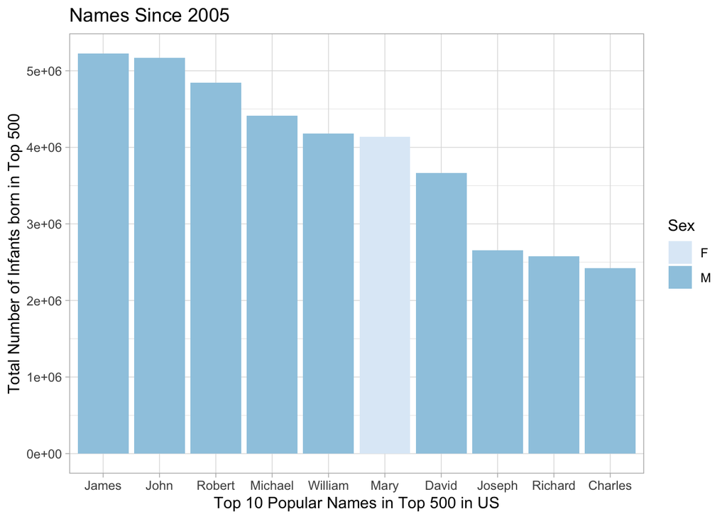

```r
babynames |>
  group_by(name, sex) |>
  summarise(total = sum(n)) |>
  arrange(desc(total)) |>
  head(10) |>

  ggplot(mapping = aes(x = fct_reorder(name,
                                       desc(total)),
                       y = total,
                       fill = sex)) +
  geom_col() +
  scale_fill_brewer() +
  theme_light() +
  labs(x = "Top 10 Popular Names in Top 500 in US",
       y = "Total Number of Infants born in Top 500",
       fill = "Sex",
       title = "Names Since 2005")
```

Go ahead and add one the `ggplot` code to make the visualization. (Made plot above)

# dplyr - `mutate()`

Use `mutate()` to create NEW columns/variables within your data set.

```r
babynames |>
  mutate(percent = round(prop*100, 2)) |>
  relocate(percent, .before = proportion)
```

```
# A tibble: 144,000 × 8
   name    sex       n  year percent proportion  rank   prop
   <chr>   <chr> <dbl> <dbl>   <dbl>      <dbl> <dbl>  <dbl>
 1 Linda   F     99693  1947    6.17     0.0562     1 0.0617
 2 Linda   F     96215  1948    6.23     0.0567     1 0.0623
 3 James   M     94761  1947    5.46     0.0518     1 0.0546
 4 Michael M     92777  1957    4.53     0.0430     1 0.0453
 5 Robert  M     91654  1947    5.28     0.0501     2 0.0528
 6 Linda   F     91017  1949    5.85     0.0532     1 0.0585
 7 Michael M     90693  1956    4.52     0.0429     1 0.0452
 8 Michael M     90614  1958    4.5      0.0427     1 0.0450
 9 James   M     88604  1948    5.32     0.0505     1 0.0532
10 Michael M     88563  1954    4.57     0.0434     1 0.0457
# ℹ 143,990 more rows
```

```r
babynames |>
  mutate(percent = round(prop*100, 2),
         nper = round(percent)) |>
  relocate(percent:nper, .before = proportion)
```

```
# A tibble: 144,000 × 9
   name    sex       n  year percent  nper proportion  rank   prop
   <chr>   <chr> <dbl> <dbl>   <dbl> <dbl>      <dbl> <dbl>  <dbl>
 1 Linda   F     99693  1947    6.17     6     0.0562     1 0.0617
 2 Linda   F     96215  1948    6.23     6     0.0567     1 0.0623
 3 James   M     94761  1947    5.46     5     0.0518     1 0.0546
 4 Michael M     92777  1957    4.53     5     0.0430     1 0.0453
 5 Robert  M     91654  1947    5.28     5     0.0501     2 0.0528
 6 Linda   F     91017  1949    5.85     6     0.0532     1 0.0585
 7 Michael M     90693  1956    4.52     5     0.0429     1 0.0452
 8 Michael M     90614  1958    4.5      4     0.0427     1 0.0450
 9 James   M     88604  1948    5.32     5     0.0505     1 0.0532
10 Michael M     88563  1954    4.57     5     0.0434     1 0.0457
# ℹ 143,990 more rows
```

## Your Turn 3

Fill in the blanks to: Rank each name *within its year and sex*.

*(Hint: Be sure to remove each `_` before running the code)*

```r
#min rank --
babynames |>
  select(name, year, sex, prop) |>
  group_by(sex, year) |>
  mutate(rank = min_rank(desc(prop))) |>
  arrange(year, sex, rank)
```

```
# A tibble: 144,000 × 5
# Groups:   sex, year [288]
   name       year sex     prop  rank
   <chr>     <dbl> <chr>  <dbl> <int>
 1 Mary       1880 F     0.0805     1
 2 Anna       1880 F     0.0297     2
 3 Emma       1880 F     0.0228     3
 4 Elizabeth  1880 F     0.0221     4
 5 Minnie     1880 F     0.0199     5
 6 Margaret   1880 F     0.0180     6
 7 Ida        1880 F     0.0168     7
 8 Alice      1880 F     0.0161     8
 9 Bertha     1880 F     0.0150     9
10 Sarah      1880 F     0.0147    10
# ℹ 143,990 more rows
```

# Take aways

- Make tables of summaries with `summarise()`
- Make new variables, with `mutate()`
- Do groupwise operations with `group_by()`
- Connect operations with `%>%` or `|>`